# Gender-based Income Gap Analysis

Pallavi Thakur

2017-03-09

This is a report presenting the anlaysis of the income gap between females and males. I have used NLSY79 (National Longitudinal Survey of Youth, 1979 cohort) data set for figuring out various factors affecting income gap.

This is a hypothesis testing based analysis.

NULL Hypthesis: There is no income gap between males and females.

The report is split into four section: Data Setup, Data Summary, Methodology, Findings, and Discussion

To start with, below scripts loads, cleanse, and transforms the data.

### Data Summary

[output not shown]

[output cut: 459 more lines]

|  | Var1 | Var2 | Freq |
| --- | --- | --- | --- |
| FEMALE | FEMALE | BLACK | 1561 |
| MALE | MALE | BLACK | 1613 |
| FEMALE | FEMALE | HISPANIC | 1002 |
| MALE | MALE | HISPANIC | 1000 |
| FEMALE | FEMALE | OTHERS | 3720 |
| MALE | MALE | OTHERS | 3790 |

There are 67 variables present in the data set. Above summary provides mean, median, quartile, etc related statistics for each variable.

#### A Brief About the Data

Of the 12686 survey respondents, 6283 were females and rest 6403 were males . There are 12 % of BLACK female respondents for 13% males, 8 % of HISPANIC female reposndents for 8 % males. Also, most of the respondents belong to NON-BLACK and NON-HISPNAIC race, this counted for 29 % females and 29 % males.

Out of all the respondents, 93% are born in the US.

|  | FEMALE | MALE |
| --- | --- | --- |
| 0 | 0.612454339885197 | 0.619634000342056 |
| 1 | 0.387545660114803 | 0.380365999657944 |

61.245434 % of the females are from ‘NONSOUTH’ region and 38.754566% females are from ‘SOUTH’ region. The values are very close to the males proportaions where 61.9634% are from NONSOUTH and 38.0366% are from SOUTH.

In this analysis of the income gap between males and females, the focus will be on below variables:

Factor Variables - race, gender, occupation.2011, region.current.2011  
Integer Variables - total.income.2011, family.size.2011, no.drinks.daily, num.job.2011

As said before, there are four factor variables and four integer variables.

#### Occupation reported in 2011

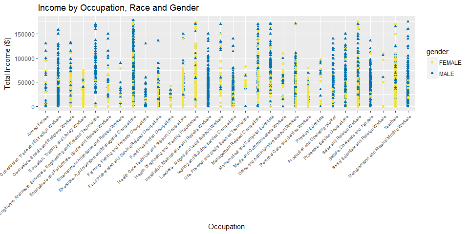

In the above table, we see the distribution of income by occupation.The color and shape denotes gender of the person reporting the salary. We see in the above diagram that females have mostly reported low salaries for various occupations. In our analysis, we will check whether this difference in incomes drives income gap or not.

#### Race

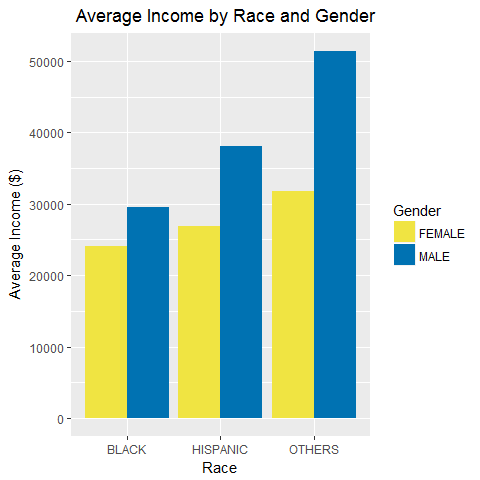

In the above figure, we see the distribution of income by race for both the gender. We see in the above diagram that there is income gap between females and males for different races. We see largest income gap in the race Others. In our analysis ahead, we will check whether this difference is statically significant.

#### Current Region of Stay

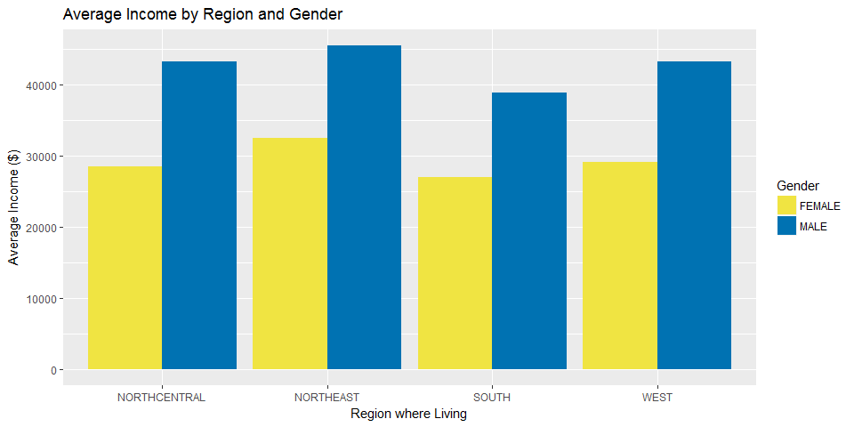

In the above figure, we see the distribution of income by region for both the gender. We see in the above diagram that there is income gap between females and males for different regions We see largest income gap in the NORTHCENTRAL and WEST regions. In our analysis ahead, we will check whether this difference is statically significant.

#### Family Size in 2011

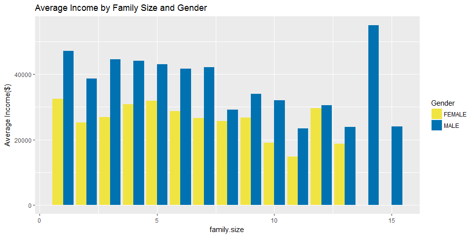

We can see in the above graph that within same family size group, males on average have higher income than females. There is visible gap between the average incomes of females and males. We will test its significane later in the analysis.

#### Number of Jobs Reported

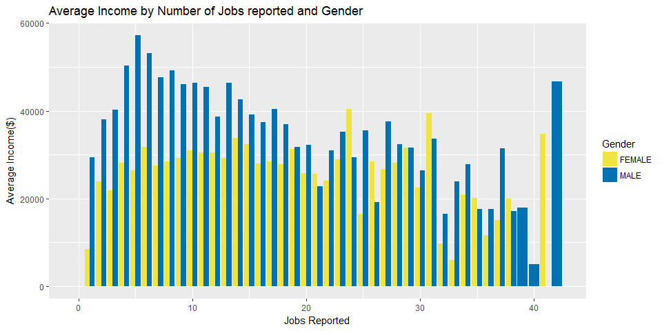

#### Alcohol Consumption

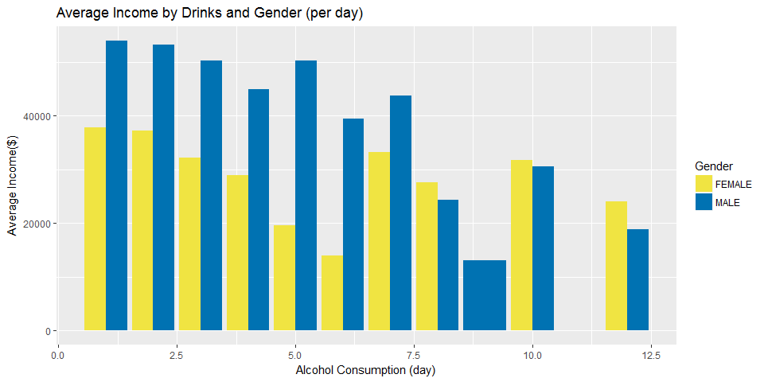

#### Educational Qualification

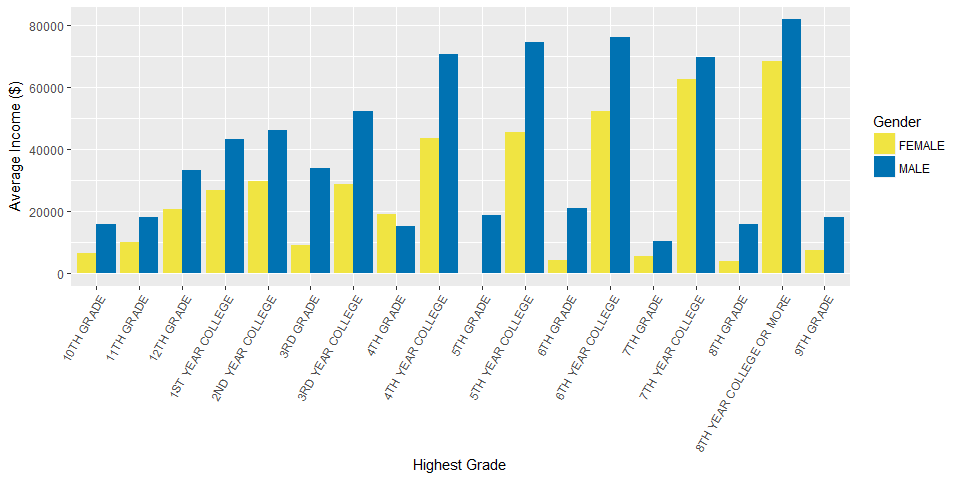

### Methodology

#### How did you deal with missing values? What impact does your approach have on the interpretation or generalizability of the resulting analysis?

I changed all the missing values to ‘NA’ as there were no informative explanation of them present.

We can not map the negative values in the variables to any specific numeric value or certain factor level . Hence, this approch helped me in working with the data records that was better reflective of the respond by the survey respondents.

#### How did you deal with topcoded variables? What impact does your approach have on the interpretation or generalizability of the resulting analysis?

Income.total.2011 integer vector had top-coded values as shown below in the diagram below.These topcoded values are an average of top 2% of the high income getters. Here, this average value represents both female and male. Because we are focused on analysing the income gap between male and female, this average is not important to us. Hence, I removed all these topcoded values so that analysis is based upon relevant data.

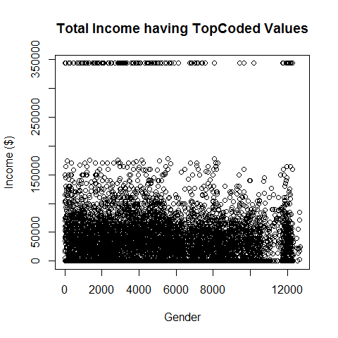

#### Did you produce any tables or plots that you thought would reveal interesting trends but didn’t?

Yes, as per my analysis (in the figure below), I found that occupation had an income gap between males and females. However, on running the model with interaction term ’occupation.2011*gender’ (in the table below), I found that the coefficients were not that significant. There is only one significant value in that interaction model.

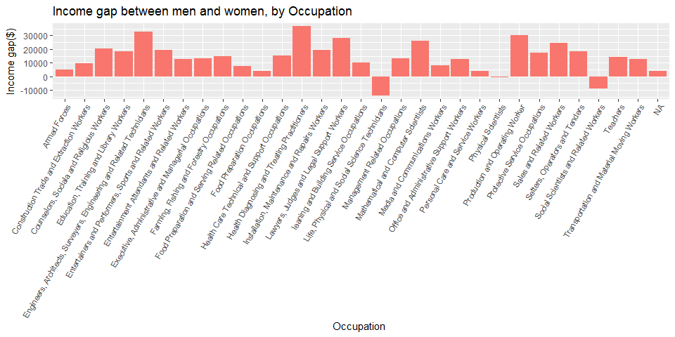

#### What relationships did you investigate that don’t appear in your findings section?

Yes, as per my analysis (in the figure below), I found that region had an income gap between males and females. However, on running the model with interaction term ’region.current.2011*gender’ (in the table below) , I found that the coefficients were not significant.

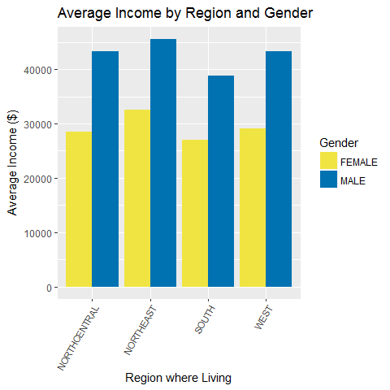

|  | Estimate | Std. Error | t value | Pr(>\|t\|) |
| --- | --- | --- | --- | --- |
| (Intercept) | 20312.5333292665 | 5427.57980227475 | 3.74246608419342 | 0.000183862535416752 |
| raceHISPANIC | 2625.57807138033 | 1194.55967132534 | 2.19794635161866 | 0.0279895833192144 |
| raceOTHERS | 8162.87164545316 | 924.849300653894 | 8.82616404605786 | 1.3876816654371e-18 |
| occupation.2011Construction Trade and Extraction Workers | -6885.89575127274 | 5400.1336663019 | -1.27513431644152 | 0.202309246660882 |
| occupation.2011Counselors, Sociala and Religious Workers | 12384.9700584457 | 5854.98881671212 | 2.11528500670997 | 0.0344452434570001 |
| occupation.2011Education, Training and Library Workers | -2499.28417807676 | 6112.08250456539 | -0.408908776380217 | 0.68262066139737 |
| occupation.2011Engineers, Architects, Surveyers, Engineering and Related Technicians | 33754.5074507562 | 6121.68668291468 | 5.51392274697157 | 3.65013764365913e-08 |
| occupation.2011Entertainers and Performers, Sports and Related Workers | -171.967333664659 | 6523.16421075979 | -0.02636256395033 | 0.978968997617646 |
| occupation.2011Entertainment Attendants and Related Workers | -10057.2035481895 | 8265.65400069624 | -1.21674625472375 | 0.223746859180728 |
| occupation.2011Executive, Administrative and Managerial Occupations | 30445.6413534333 | 5314.80004851026 | 5.72846411446226 | 1.06077361885387e-08 |

[output cut: 31 more lines]

#### What’s the analysis that you finally settled on? What income and gender related factors do you investigate in the final analysis?

Finally, I added highest.grade.2011 variable to the models with the interaction term. Income and gender are getting impacted by race, occupation, and highest degree.

### Findings:

#### Statistical Significance Testing

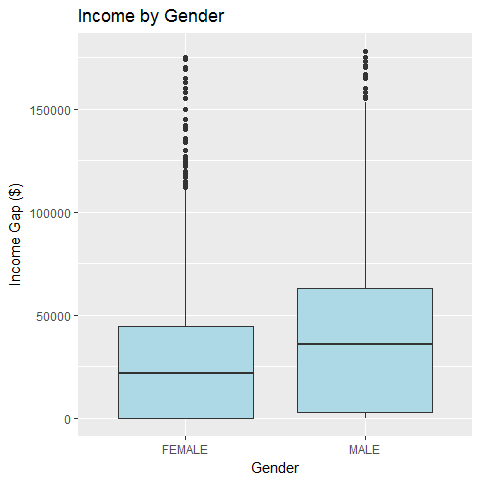

We can see that the mean income of females is lower than that of males. This plot suggests that gender is associated with income. We can also see outliers incomes in the upper part of box plot in both female and male’s incomes.

```
##   gender total.income.2011.mean total.income.2011.se
## 1 FEMALE             28492.3221             505.8242
## 2   MALE             41834.0904             675.9342
```

We can see that the mean income of females is lower than that of males. This plot suggests that gender is associated with income. We can also see outliers incomes in the upper part of box plot in both female and male’s incomes.

```
##
##  Welch Two Sample t-test
##
## data:  total.income.2011 by gender
## t = -15.803, df = 6202.5, p-value < 2.2e-16
## alternative hypothesis: true difference in means is not equal to 0
## 95 percent confidence interval:
##  -14996.78 -11686.76
## sample estimates:
## mean in group FEMALE   mean in group MALE
##             28492.32             41834.09
```

Our study finds that income is on average -13341.8g higher in males compared to the females (t-statistic -15.8, p=0, 95% CI [-14996.8, -11686.8] dollars).

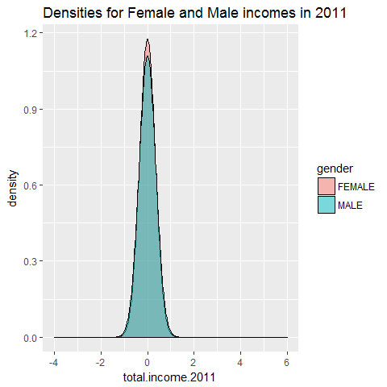

Above plot is of kernel density estimate.The density of male and female income is very much overlapping.

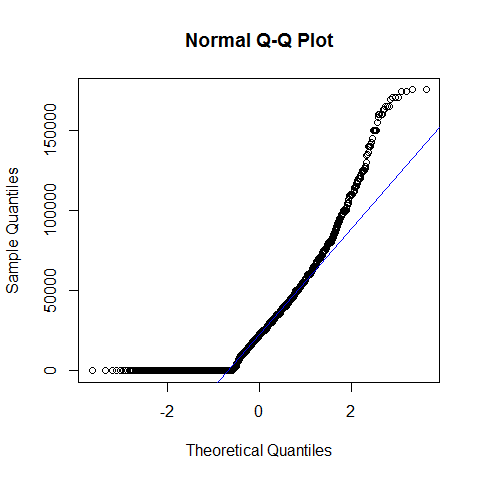

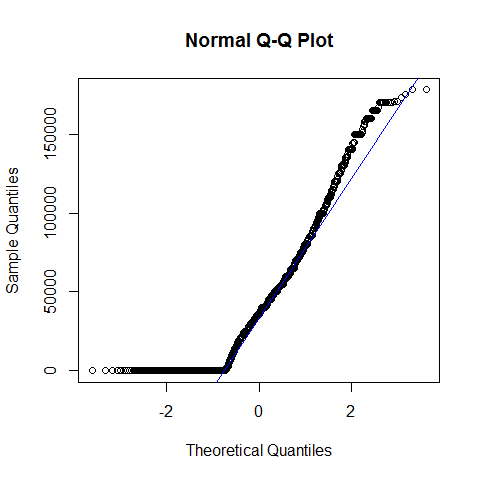

The plot above is for income of the males. It is highly right skewed as the right tail starts deviating before quartile point 2. We see, the distribustion going away from the normal around ’theoretical quartiles’2, but it agaian comes towards the center line. However, the concentration of the data points decreases. Hence, the data is non-normal.

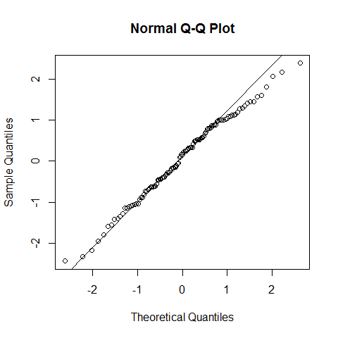

Both the tail end in the upper diagram deviates from the straight line denoting normalancy. As the data on the above plot doesnot lie on a straight line, we can say that it is not normal.

#### Statistical Significance testing

We will start test our variables one by one to test whether they display any statiscal significan or not.

#### Race (variable name = race)

|  | gender | race | total.income.2011 |
| --- | --- | --- | --- |
| 1 | FEMALE | BLACK | 24095.8297297297 |
| 2 | MALE | BLACK | 29498.4573346117 |
| 3 | FEMALE | HISPANIC | 26931.6274787535 |
| 4 | MALE | HISPANIC | 38056.5833333333 |
| 5 | FEMALE | OTHERS | 31836.0653996646 |
| 6 | MALE | OTHERS | 51394.8666249217 |

We can see that the mean of income by race for females and males has a huge difference. For example, The mean income for Hisplanic females is 26931.6274788, whereas for Hispanic males is 38056.5833333. There is a huge differece of 11124.9558546.

It looks like there’s some association, but we don’t yet know if it’s statistically significant.This is explained ahead along with graphical plot.

```
##               Df        Sum Sq      Mean Sq F value Pr(>F)
## race           2  282562114231 141281057116   122.4 <2e-16 ***
## gender         1  311771684745 311771684745   270.1 <2e-16 ***
## Residuals   6877 7937287592137   1154178798
## ---
## Signif. codes:  0 '***' 0.001 '**' 0.01 '*' 0.05 '.' 0.1 ' ' 1
## 5805 observations deleted due to missingness
```

The p-value is significant at the 0.05 level, so the data suggests that there is an association between total.income.2011 and race for male and female. In other words, average total.income.2011 varies across the three racial groups and genders considered in the data.

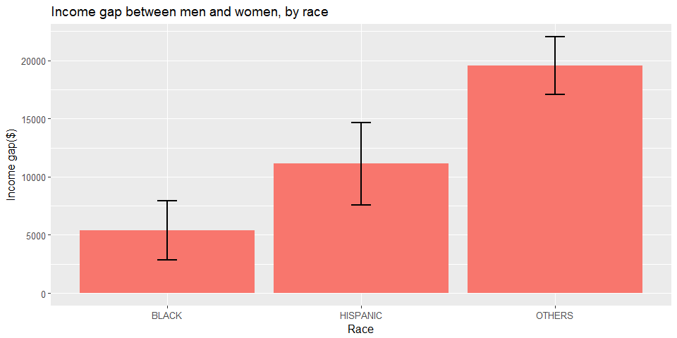

In the above graph, we can clearly see the income gap difference by race. Here, non-black and non-hispanic race females and males show most income gap whereas black males and females shows the least income gap.

We have already checked through ANOVA above that this difference is statistically significant.

#### Occupation in 2011 (variable name = occupation.2011)

|  | gender | occupation.2011 | total.income.2011 |
| --- | --- | --- | --- |
| 1 | FEMALE | Armed Forces | 31650 |
| 2 | MALE | Armed Forces | 36900.8518518519 |
| 3 | FEMALE | Construction Trade and Extraction Workers | 21360.25 |
| 4 | MALE | Construction Trade and Extraction Workers | 30942.3917808219 |
| 5 | FEMALE | Counselors, Sociala and Religious Workers | 33719.4395604396 |
| 6 | MALE | Counselors, Sociala and Religious Workers | 54100 |
| 7 | FEMALE | Education, Training and Library Workers | 22492.7857142857 |
| 8 | MALE | Education, Training and Library Workers | 40740 |
| 9 | FEMALE | Engineers, Architects, Surveyers, Engineering and Related Technicians | 46266.6666666667 |
| 10 | MALE | Engineers, Architects, Surveyers, Engineering and Related Technicians | 78971.3896103896 |

[output cut: 50 more lines]

It looks like there’s some association, but we don’t yet know if it’s statistically significant. This is explained ahead along with graphical plot.

```
##                   Df        Sum Sq      Mean Sq F value Pr(>F)
## occupation.2011   29 1580760918413  54508997187   57.58 <2e-16 ***
## gender             1  269994068487 269994068487  285.21 <2e-16 ***
## Residuals       6283 5947777924031    946646176
## ---
## Signif. codes:  0 '***' 0.001 '**' 0.01 '*' 0.05 '.' 0.1 ' ' 1
## 6372 observations deleted due to missingness
```

The p-value is significant at the 0.05 level, so the data suggests that there is an association between total.income.2011 and various occupations for male and female. In other words, average total.income.2011 varies across all the occupations and genders considered in the data.

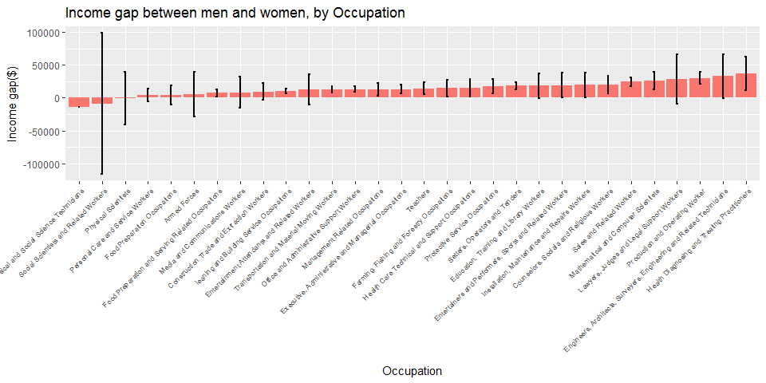

In the above graph, we can clearly see the income gap difference by occupation. Here, occupations ‘Health Disgonosing and Treating Practitioners Production’, females and males show most income gap whereas Social Science technician males and females shows the inverse income gap.

#### Region Staying (variable name = region.current.2011)

|  | gender | region.current.2011 | total.income.2011 |
| --- | --- | --- | --- |
| 1 | FEMALE | NORTHCENTRAL | 28509.0120772947 |
| 2 | MALE | NORTHCENTRAL | 43347.0212201591 |
| 3 | FEMALE | NORTHEAST | 32498.4933333333 |
| 4 | MALE | NORTHEAST | 45580.9090909091 |
| 5 | FEMALE | SOUTH | 27022.0601941748 |
| 6 | MALE | SOUTH | 38871.646004481 |
| 7 | FEMALE | WEST | 29120.671071953 |
| 8 | MALE | WEST | 43301.7913561848 |

It looks like there’s some association, but we don’t yet know if it’s statistically significant.This is explained ahead along with graphical plot.

```
##                       Df        Sum Sq      Mean Sq F value     Pr(>F)
## gender                 1  299246307782 299246307782 251.786    < 2e-16 ***
## region.current.2011    3   31035348145  10345116048   8.704 0.00000924 ***
## Residuals           6822 8107918550774   1188495830
## ---
## Signif. codes:  0 '***' 0.001 '**' 0.01 '*' 0.05 '.' 0.1 ' ' 1
## 5859 observations deleted due to missingness
```

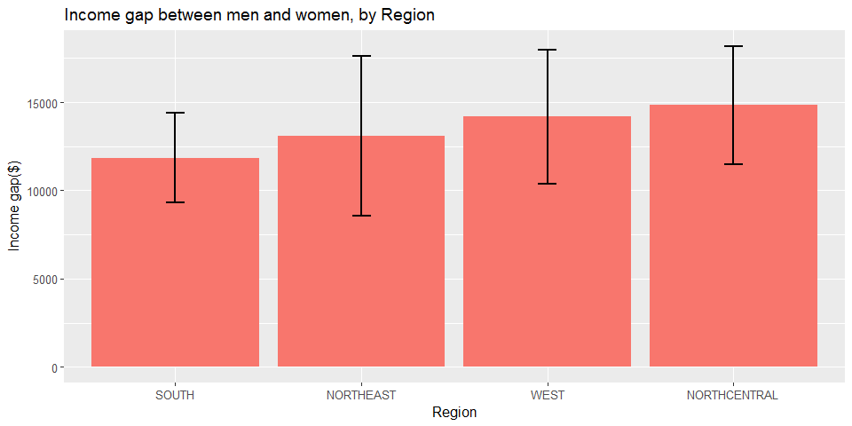

In the above graph, we can clearly see the income gap difference by region. Here, occupations Northcentral females and males show most income gap whereas South males and females shows the least income gap.

#### Number of Jobs Reported (variable name = num.jobs.2011)

|  | gender | num.job.2011 | total.income.2011 |
| --- | --- | --- | --- |
| 1 | FEMALE | 1 | 8500 |
| 2 | MALE | 1 | 29350 |
| 3 | FEMALE | 2 | 23874.8313253012 |
| 4 | MALE | 2 | 38122.9491525424 |
| 5 | FEMALE | 3 | 21838.9217391304 |
| 6 | MALE | 3 | 40196.7142857143 |
| 7 | FEMALE | 4 | 28158.4969325153 |
| 8 | MALE | 4 | 50284.5859375 |
| 9 | FEMALE | 5 | 26475.8571428571 |
| 10 | MALE | 5 | 57274.0898203593 |

[output cut: 80 more lines]

We can see that number of jobs changed does show difference in income between females and males. Hence, for respondents who have changed same number of jobs, the income for males is higher than females. For example, in the above table, the females who changed 4 jobs earns on average $28158.4969325, whereas for males it is 50284.5859375. There is a differece of 22126.089005.

It looks like there’s some association, but we don’t yet know if it’s statistically significant. This is explained ahead along with graphical plot.

```
##                Df        Sum Sq      Mean Sq F value           Pr(>F)
## gender          1  305509270218 305509270218  257.29          < 2e-16 ***
## num.job.2011    1   59072108385  59072108385   49.75 0.00000000000192 ***
## Residuals    6878 8167040012510   1187414948
## ---
## Signif. codes:  0 '***' 0.001 '**' 0.01 '*' 0.05 '.' 0.1 ' ' 1
## 5805 observations deleted due to missingness
```

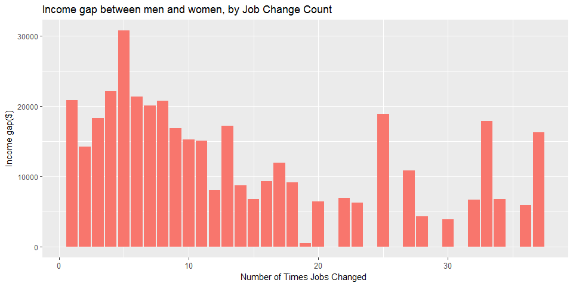

#### Family Size (variable name = family.size.2011)

|  | gender | family.size.2011 | total.income.2011 |
| --- | --- | --- | --- |
| 1 | FEMALE | 1 | 27161.5129604366 |
| 2 | MALE | 1 | 29775.8162393162 |
| 3 | FEMALE | 2 | 29096.6115351993 |
| 4 | MALE | 2 | 41797.3083604777 |
| 5 | FEMALE | 3 | 31180.4039653036 |
| 6 | MALE | 3 | 45454.0914826498 |
| 7 | FEMALE | 4 | 28292.5965583174 |
| 8 | MALE | 4 | 55705.2576064909 |
| 9 | FEMALE | 5 | 25557.3946188341 |
| 10 | MALE | 5 | 54546.7095238095 |

[output cut: 14 more lines]

We can see that the mean of income by family size for females and males has a difference. For example, The mean income for females having 6 family members is 21318.5058824, whereas for males it is 43252. There is a huge differece of 21933.4941176.

It looks like there’s some association, but we don’t yet know if it’s statistically significant. This is explained ahead along with graphical plot.

```
##                    Df        Sum Sq      Mean Sq F value           Pr(>F)
## gender              1  305509270218 305509270218  257.20          < 2e-16
## family.size.2011    1   56288443090  56288443090   47.39 0.00000000000634
## Residuals        6878 8169823677804   1187819668
##
## gender           ***
## family.size.2011 ***
## Residuals
## ---
## Signif. codes:  0 '***' 0.001 '**' 0.01 '*' 0.05 '.' 0.1 ' ' 1
## 5805 observations deleted due to missingness
```

The p-value is significant at the 0.05 level, so the data suggests that there is an association between total.income.2011 and family size for male and female. In other words, family size kept same, there is an income gap between the genders.

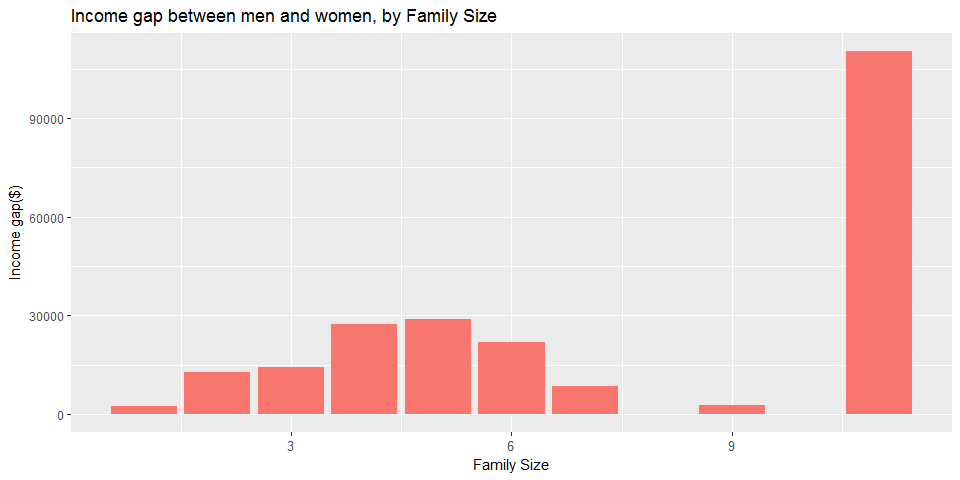

#### 6.. Highest Ediucation (variable name = highest.2011.grade)

|  | gender | highest.2011.grade | total.income.2011 |
| --- | --- | --- | --- |
| 1 | FEMALE | 10TH GRADE | 6521.14492753623 |
| 2 | MALE | 10TH GRADE | 15726.8395061728 |
| 3 | FEMALE | 11TH GRADE | 10127.1578947368 |
| 4 | MALE | 11TH GRADE | 17978.9626168224 |
| 5 | FEMALE | 12TH GRADE | 20820.8927835052 |
| 6 | MALE | 12TH GRADE | 33441.0907936508 |
| 7 | FEMALE | 1ST YEAR COLLEGE | 26887.4901960784 |
| 8 | MALE | 1ST YEAR COLLEGE | 43268.0231660232 |
| 9 | FEMALE | 2ND YEAR COLLEGE | 29705.3381995134 |
| 10 | MALE | 2ND YEAR COLLEGE | 46265.2524590164 |

[output cut: 26 more lines]

We can see that the mean of income by highereducation for females and males has a huge difference. It looks like there’s some association, but we don’t yet know if it’s statistically significant. This is explained ahead along with graphical plot.

```
##                      Df        Sum Sq      Mean Sq F value Pr(>F)
## gender                1  304704846470 304704846470  313.60 <2e-16 ***
## highest.2011.grade   17 1559159531012  91715266530   94.39 <2e-16 ***
## Residuals          6860 6665328063788    971622167
## ---
## Signif. codes:  0 '***' 0.001 '**' 0.01 '*' 0.05 '.' 0.1 ' ' 1
## 5807 observations deleted due to missingness
```

The p-value is significant at the 0.05 level, so the data suggests that there is an association between total.income.2011 and highest education attained for male and female. In other words, average total.income.2011 varies across all the highest education and genders considered in the data.

#### Linear Regression

|  | Estimate | Std. Error | t value | Pr(>\|t\|) |
| --- | --- | --- | --- | --- |
| (Intercept) | 4938.49643714476 | 5808.69479615594 | 0.850190380188841 | 0.395251999936515 |
| raceHISPANIC | 5122.15571566753 | 1156.22876960338 | 4.43005385294519 | 9.58256226690423e-06 |
| raceOTHERS | 7518.14581870297 | 887.210842777679 | 8.47391111132633 | 2.93187640009281e-17 |
| genderMALE | 15461.2946567735 | 870.524571118907 | 17.7608940284141 | 6.99176293555798e-69 |
| family.size.2011 | 1152.94108402558 | 265.290264516543 | 4.3459607766861 | 1.40877078143637e-05 |
| num.job.2011 | -670.793947927367 | 52.7938734669812 | -12.7059051339906 | 1.55652025805142e-36 |
| occupation.2011Construction Trade and Extraction Workers | -1050.25463948494 | 5162.69749911864 | -0.203431372778327 | 0.838804540488628 |
| occupation.2011Counselors, Sociala and Religious Workers | 1120.33380950239 | 5612.47752775055 | 0.199614841032854 | 0.84178835031067 |
| occupation.2011Education, Training and Library Workers | -5676.6410825252 | 5839.80834748909 | -0.972059482905111 | 0.331058786771913 |
| occupation.2011Engineers, Architects, Surveyers, Engineering and Related Technicians | 27867.0425980292 | 5853.02739137185 | 4.7611331255871 | 1.96871959568722e-06 |

[output cut: 45 more lines]

Interpretation of the Coefficients This model assumes independent effects for all the variables mentioned. In the above table, we have 55 coefficients.

All the factor variables are split into levels to make an individual coefficient. For example, ‘region.current.2011’ factor got split into 4 levels, where the one coming first in the alphabetic order became intercept.

Interpretation of the P-value

In the above table, column ‘Pr(>|t|)’ represents p-value of the predictor variables metioned in the first column. We know that a predictor variable is significant when it has p-value below 0.05.

Looking at p-values in the above table, there are 22 significant values across all variables. Some of the variables are: region.current.2011SOUTH, family.size.2011, num.job.2011, raceOTHERS, and raceHISPANIC.

There is one negatively associated significant predictor variable, i.e. num.job.2011. There is an example of positive and negative associated predictor variables in the table below:

Interpretation of the Significance

In the table above, a positive Estimate shows positive association wheras negative Estimate shows negative. Explanation of few variables is mentioned in the table below.

Table: Significant Predictor Variables (a few)

[output not shown]

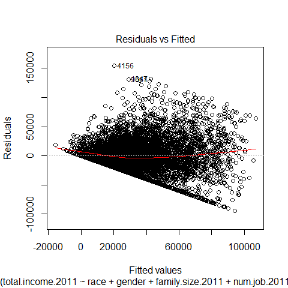

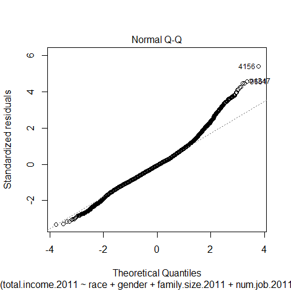

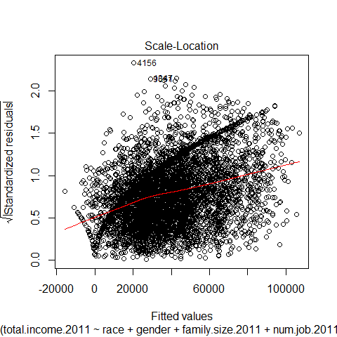

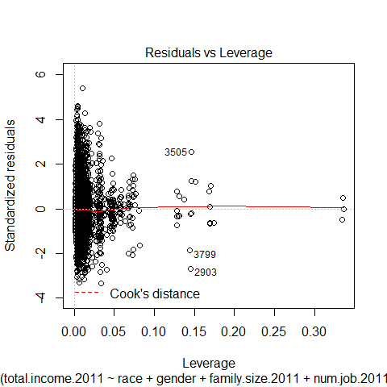

**Description of Diagnostic Plots**

**Residuals vs. Fitted**

There is a indication of non-linearity present in this plot. Furthermore, we see that the variance appears to be increasing across fitted value.

**Normal QQ plot**

**Scale-location plot**

We see a clear increasing trend in residual variance that runs through most of the plot. This is indicated by the upward slope of the red line, which we can interpret as the standard deviation of the residuals at the given level of fitted value.

**Residuals vs Leverage.**

None of the points appear to be outliers.

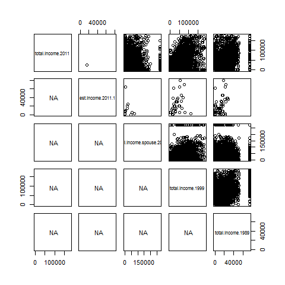

|  | Estimate | Std. Error | t value | Pr(>\|t\|) |
| --- | --- | --- | --- | --- |
| (Intercept) | 10042.3921320089 | 5808.27079979111 | 1.72898139190928 | 0.0838620686647314 |
| genderMALE | 15409.253987031 | 875.368771555585 | 17.6031570781852 | 1.00234760697967e-67 |
| family.size.2011 | 1219.02711997488 | 265.700360782028 | 4.58797690897731 | 4.56347105938101e-06 |
| num.job.2011 | -655.534247878535 | 53.0352447134396 | -12.3603511480059 | 1.09158561935981e-34 |
| occupation.2011Construction Trade and Extraction Workers | -929.363164156329 | 5190.97331166571 | -0.179034471640947 | 0.857916468541763 |
| occupation.2011Counselors, Sociala and Religious Workers | 284.578873339514 | 5642.8324971715 | 0.0504319193387648 | 0.959779820905385 |
| occupation.2011Education, Training and Library Workers | -5492.63634697436 | 5872.38804201601 | -0.935332663249673 | 0.349653215401136 |
| occupation.2011Engineers, Architects, Surveyers, Engineering and Related Technicians | 29496.4089854527 | 5881.60787604459 | 5.01502473593823 | 5.44972642276177e-07 |
| occupation.2011Entertainers and Performers, Sports and Related Workers | -6838.4008520629 | 6271.11482208953 | -1.09046015677709 | 0.275552756777204 |
| occupation.2011Entertainment Attendants and Related Workers | -6643.22375423156 | 7932.24192574016 | -0.837496361863885 | 0.402345814446267 |

[output cut: 43 more lines]

```
## Analysis of Variance Table
##
## Model 1: total.income.2011 ~ gender + family.size.2011 + num.job.2011 +
##     occupation.2011 + highest.2011.grade + region.current.2011
## Model 2: total.income.2011 ~ race + gender + family.size.2011 + num.job.2011 +
##     occupation.2011 + highest.2011.grade + +region.current.2011
##   Res.Df           RSS Df   Sum of Sq      F    Pr(>F)
## 1   6217 5200036923520
## 2   6215 5140505700374  2 59531223146 35.987 2.889e-16 ***
## ---
## Signif. codes:  0 '***' 0.001 '**' 0.01 '*' 0.05 '.' 0.1 ' ' 1
```

|  | Estimate | Std. Error | t value | Pr(>\|t\|) |
| --- | --- | --- | --- | --- |
| (Intercept) | 8348.62507035262 | 5832.53697636075 | 1.43138827995254 | 0.152369263656951 |
| raceHISPANIC | 3159.60097189527 | 1539.7522796345 | 2.05201902519364 | 0.0402096298004653 |
| raceOTHERS | 3176.30347424733 | 1197.22972932597 | 2.65304427082308 | 0.00799723270239815 |
| genderMALE | 10094.6897421901 | 1402.26488815974 | 7.1988465427797 | 6.78926163927517e-13 |
| family.size.2011 | 1108.71183966181 | 264.91369976331 | 4.18518121430641 | 2.88869865161207e-05 |
| num.job.2011 | -654.185458512501 | 52.7787565941886 | -12.3948630230621 | 7.1794942652376e-35 |
| occupation.2011Construction Trade and Extraction Workers | -1827.81885335907 | 5153.28618931127 | -0.354689956313752 | 0.722833914309662 |
| occupation.2011Counselors, Sociala and Religious Workers | -44.0788189303434 | 5604.25027323742 | -0.00786524812084817 | 0.993724757180174 |
| occupation.2011Education, Training and Library Workers | -6692.99096404687 | 5831.00422082632 | -1.14782818028871 | 0.25108369561881 |
| occupation.2011Engineers, Architects, Surveyers, Engineering and Related Technicians | 26181.4410301253 | 5848.4101708099 | 4.47667661218426 | 7.71684037081773e-06 |

[output cut: 47 more lines]

Interpretation of Coefficients There are two estimated coefficients for this interaction term. These coefficients correspond to differences in earnings across gender and race that aren’t accounted for by a model that assumes independent effects for race and gender (as in nlsy.lm1). That is, the income difference between men and women appears to depend strongly on the individual’s race. For instance, the income difference among mixed-race men and mixed-race women is $9045 more than the difference between black men and black women. Race is a factor that is highly associated with the income gap between men and women.

Interpretation of Output The Estimate for the two coefficients are positively associated with the intercept. Also, looking at the P-value, it can be identified that both the coefficients are highly significant. For instance, all the other factor in the model staying same, the income difference between hispanic men and hispanic women is $4079 more than the difference between black men and black women.

```
## Analysis of Variance Table
##
## Model 1: total.income.2011 ~ race + gender + family.size.2011 + num.job.2011 +
##     occupation.2011 + highest.2011.grade + +region.current.2011
## Model 2: total.income.2011 ~ race + gender + family.size.2011 + num.job.2011 +
##     occupation.2011 + highest.2011.grade + region.current.2011 +
##     race:gender
##   Res.Df           RSS Df   Sum of Sq      F       Pr(>F)
## 1   6215 5140505700374
## 2   6213 5116092250128  2 24413450246 14.824 0.0000003779 ***
## ---
## Signif. codes:  0 '***' 0.001 '**' 0.01 '*' 0.05 '.' 0.1 ' ' 1
```

On comparing two models (the one with interaction variable and the one without, we found that the p-value is statistically significant as it is 0.0000003779 (it has to be <0.05). Hence, we can reject the null hypothesis that the income gap is the same across all the race categories. In other words, race is a highly significant factor impacting income, therefore, all other variables kept same, the data suggests that the income gap between men and women does vary with race.

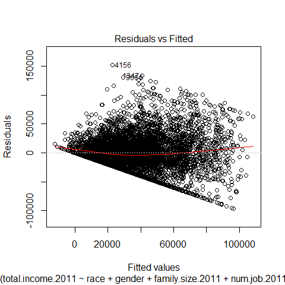

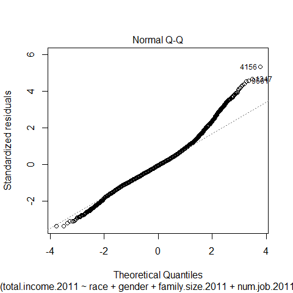

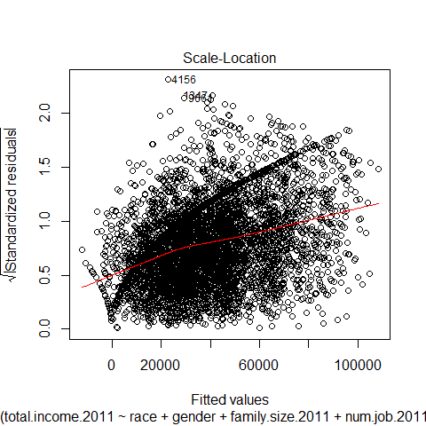

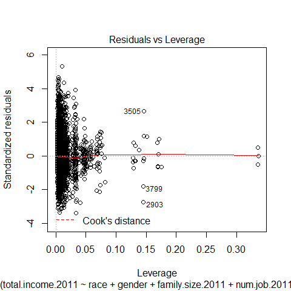

**Description of Diagnostic Plots**